```python
import numpy as np
from matplotlib import pyplot as plt
import warnings
```

# The Logistic Map

The [logistic map](https://en.wikipedia.org/wiki/Logistic_map) $x_{i+1}=rx_{i}(1-x_{i})$ with parameter $r$ is often cited as an example of chaotic behavior. Here's how it works:

1. Generate a bunch of $x_{i}$ values between zero and one
2. Apply the logistic map $x_{i+1} = rx_{i}(1-x_{i})$ to those values to get new x values for some value of $r$ (between 0 and 4)
3. Plug your new values back into the equation and repeat. (do step 2 an infinite number of times)
4. Notice that nearby points are really far away

**Why x values between zero and one?** In short, when $r$>1, $x$ values outside the [0,1] range blow-up. And fixing that by keeping $r$<1 makes things super-boring (all points get pulled to zero). Here's a proof that $x_{i}$<0 blows up when the logistic map is applied by expanding the inequality:

\begin{align*} & x_{i} < 0 &\\ & -x_{i} > 0 &\text{ multiply both sides by -1, flipping the inequality} \\ & 1-x_{i} > 1 &\text{ add 1 to both sides}\\ & rx_{i}(1-x_{i}) < rx_{i} &\text{ multiply both sides by } rx_{i} \text{ which is negative, flipping the inequality} \end{align*}

Now we know $x_{i+1} = rx_{i}(1-x_{i})$ is smaller than $rx_{i}$ (and therefore smaller than $x_{i}$ since $rx_{i}<x_{i}$ when $r$>1 and $x_{i}$<0). By induction, this suggests that $x_{i+n} < r^n x_{i}$. As a result, which ensures that negative values blow-up exponentially in a logistic map for $r$>1.

Now that this is proved, its easy to show that $x_{i}$>1 blows up if $r$ > 1. After all, if $x_{i}$>1, then $(1-x_{i})$ is negative, which makes the output of the map $rx_{i}(1-x_{i})$ negative as well. Since negative valus blow-up, we already know that this results in a blow-up. It's nice when none of the values in the selected range blow up.

**Why r values between zero and four?** The maximum value of a logistic map between zero and one is given at $x_{i}=(1-x_{i+1})=1/2$ which means $x_{i+1}=r(1/2)(1/2)=r/4$. As a result, $x_{i}$=0.5 gets mapped to $x_{i+1}$>1 if $r$>4. Since we know that x values above 1 get sent to negative values which then blow-up, we know that $x$=0.5 blows up for $r$>4.

This write-up discusses the logistic map but the code is designed to be flexible. The sin map (of which, the logistic map serves as a 2nd order Taylor Approximation for) and tent map are also included here for those interested in generating plots for alternative maps. Just change "map_name" to "Sin Map" or "Tent Map". I've also included "Borked Logistic Map", which is similar to the logistic map but has a jump around the peak. It produces some interesting behavior but the solutions later in this notebook take forever to run. All the maps conceptually do the same thing -- of folding points between 0.5 and 1 back to the range 0 to 0.5. This qualitatively similar behavior is probably why the tent-map is actually viewed as a [non-linear transformation](https://en.wikipedia.org/wiki/Dyadic_transformation#Relation_to_tent_map_and_logistic_map) of the logistic map. Something similar probably holds for the sine map -- and more generally any map with a single hump that can be locally approximated with a quadratic function.

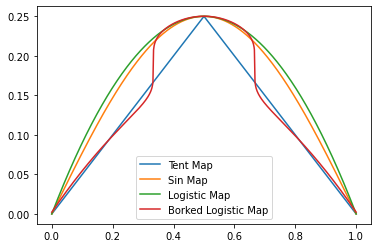

```python
map_name = "Logistic Map"
# map_name = "Tent Map"
# map_name = "Sin Map"

#  define maps
# tent map
def tent_map(x,r):
    x = x.copy()
    less_idx = (x < 0.5)
    more_idx = (0.5 <= x)
    x[less_idx] = 0.5*r*x[less_idx]
    x[more_idx] = 0.5*r*(1-x[more_idx])
    return x

# sin(x) looks a lot like x*(1-x) and works very similarly!
sin_map = lambda x,r: (0.25)*r*np.sin(np.pi*x)

# logistic map
logistic_map = lambda x,r: r*x*(1-x)

# borked logistic map (map I made up -- takes the peak of the logistic map and boops it upward)
borked_logistic_map = lambda x,r: (r/2)*(x*(1-x) - 0.2 * np.sign(1/3-x)*np.abs(1/3-x)**(0.2) * np.sign(2/3-x)*np.abs(2/3-x)**(0.2)+ 0.1525)


# create map dict
map_dict = {'Tent Map':tent_map,
            'Sin Map': sin_map,
            'Logistic Map': logistic_map,
            'Borked Logistic Map': borked_logistic_map}

x = np.linspace(0,1,1000)
for i in map_dict.keys():
    plt.plot(x, map_dict[i](x, 1), label = i)
plt.legend()
```

```python
# select map function
f = map_dict[map_name]

# function that iterates the map a specified number of times
def f_iter(x, r, iters):
    x_f = x
    for i in range(iters):
        x_f = f(x_f, r)
    return x_f
```

While this can't really be done an infinite number of times, it can be down a whole lot. Here's what the map looks like at different values of $r$.

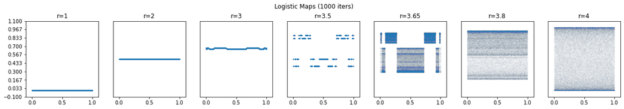

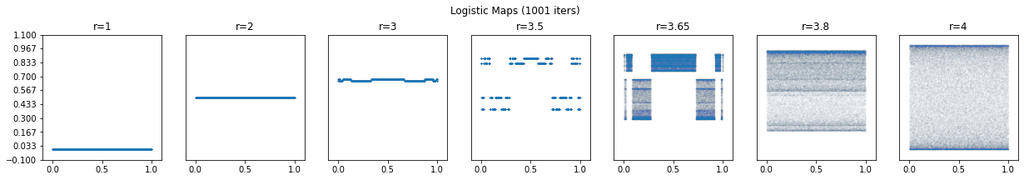

```python
# generate a bunch of x values to start with
x = np.linspace(0,1,100000)

# create subplots for viewing maps with different r parameters
fig, axes = plt.subplots(nrows = 1, ncols = 7, figsize = [21,3])
fig.subplots_adjust(top = 0.82)
fig.suptitle('{0}s (1000 iters)'.format(map_name))
plt.xlim([-0.1, 1.1])
plt.ylim([-0.1, 1.1])
for ax, r in zip(axes, [1, 2, 3, 3.5, 3.65, 3.8 , 4]):
    # iterate the map with a given r value and plot it
    ax.plot(x, f_iter(x, r, 1000), '.', MarkerSize = 1, alpha = 0.01)
    ax.set_title('r={0}'.format(r))
    ax.set_xlim([-0.1,1.1])
    ax.set_ylim([-0.1,1.1])
    ax.set_yticks([])
# add y-axis tick marks on left-most plot
res = axes[0].set_yticks(np.linspace(-0.1, 1.1, 10))

fig, axes = plt.subplots(nrows = 1, ncols = 7, figsize = [21,3])
fig.subplots_adjust(top = 0.82)
fig.suptitle('{0}s (1001 iters)'.format(map_name))
plt.xlim([-0.1, 1.1])
plt.ylim([-0.1, 1.1])
for ax, r in zip(axes, [1, 2, 3, 3.5, 3.65, 3.8 , 4]):
    # iterate the map with a given r value and plot it
    ax.plot(x, f_iter(x, r, 1001), '.', MarkerSize = 1, alpha = 0.01)
    ax.set_title('r={0}'.format(r))
    ax.set_xlim([-0.1,1.1])
    ax.set_ylim([-0.1,1.1])
    ax.set_yticks([])
# add y-axis tick marks on left-most plot
res = axes[0].set_yticks(np.linspace(-0.1, 1.1, 10))
```

As expected, all results remain on the [0,1] interval (otherwise they would blow-up and Python would complain). For $r=1$ or $2$, all points wind up mapped to the same value. For $r=3$ or $3.5$ points get mapped to multiple values. And for $r=3.8$ or $4.0$, things look messy. Unsurprisingly, most people are interested in r values above 3.5.

# Bifurcation Diagrams

When values are fed into the logistic map there are a number of possibilities: they can bounce around chaotically, they can cycle between a number of finite values, or they can converge on a fixed point. The above plots help give a sense of which of these possibilities are occuring and where:

- At $r=1$, there is single stable fixed point around zero.
- At $r=2$, the single stable fixed point has moved upward to around 0.5.
- At $r=3$, the fixed point appears to have bifurcated into two nearby values. However, now the images corresponding to the 1000th and 1001st iterations do not match up. This is because neither of these is a stable fixed point. Instead both are part of a stable oscillating cycle.
- At $r=3.5$, the cycling continues but there are now four points to cycle between.
- At $r=3.8$, there are no longer clear differences between the 1000th and 1001st cycle and there are no discrete points -- only denser and less dense regimes that values bounce chaotically around in.
- At $r=4$, there is still chaos. There are two dense bands at zero and one but no others.

Something to note here is that, once in the chaotic regime, there is no longer any meaningful way to distinguish which output values were produced by which input values. For $r$≤3.65, the pattern that the output of the logistic map makes with the inputs is suggestive of cycles but, as things grow more chaotic, patterns cannot be made out.

This is exciting! It means that, when looking at the chaotic regime, we have an excuse to completely neglect the input x values entirely and focus only on the distribution of the output values of the logistic map. We can take the 2d plots above and smoosh the x-axis to make each $r$ value correspond to a 1-dimensional distribution of output points instead of a 2d map of input values to output values. This gives us extra dimension to do our visualizations with -- which we can use for the $r$ parameter.

Plotting the density of output points of the logistic map against $r$ values gives a bifurcation plot. Here's how to make them:

```python
def r_screen(iters = 1, r_vals = np.linspace(0, 4, 100), x_num = 2**10):
    # values for storing r, x_eq, x_num
    vals = np.zeros(shape = (1, 2))

    # initial x values to iterate on
    x_i = np.linspace(0, 1, x_num)

    # loop through all r values
    for r in r_vals:
        # perform iterations to get the distribution of output points
        x_f = f_iter(x_i, r, iters).reshape(-1,1)

        # concatenate new r_vals and distributions
        r_vals = np.tile(r, reps = [x_num,1])
        new_vals = np.concatenate([r_vals, x_f], axis = 1)

        # concatenate the distribution at the new r value with the old distributions
        vals = np.concatenate( [vals, new_vals] )
    return vals
```

```
(3.3, 4.0)
```

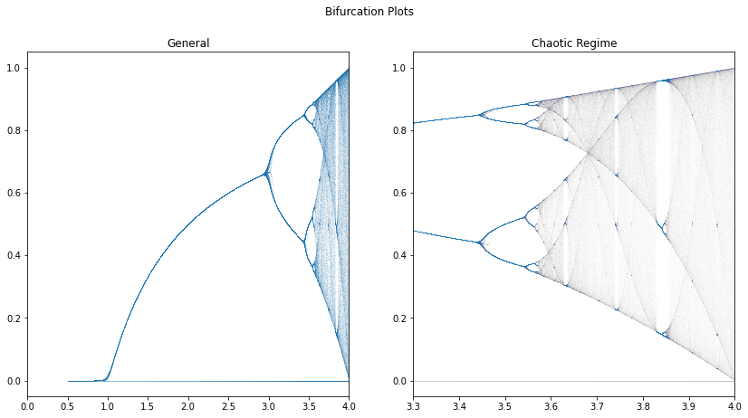

```python
fig, (ax1, ax2) = plt.subplots(nrows = 1, ncols = 2, figsize = [14,7])
fig.suptitle('Bifurcation Plots')

# logspacing to focus density on higher values
r_vals = 4.5-np.logspace(np.log10(0.5), np.log10(4), 10000)
vals0_1 = r_screen(iters = 50, x_num = 2**6, r_vals = r_vals)
ax1.plot(vals0_1[:,0], vals0_1[:,1], '.', MarkerSize = 0.3, alpha = 0.05)
ax1.set_title('General')
ax1.set_xlim([0,4])

r_vals = 7.3-np.logspace(np.log10(3.3), np.log10(4), 10000)
vals = r_screen(iters = 100, x_num = 2**7, r_vals = r_vals)
ax2.plot(vals[:,0], vals[:,1], '.', MarkerSize = 0.3, alpha = 0.01)
ax2.set_title('Chaotic Regime')
ax2.set_xlim([3.3,4])
```

The above plots are called bifurcation plots because they give a sense of how each of the cycles in the logistic map bifurcate as the $r$ parameter is varied. The single fixed point up until $r$=3 is visible in the left image. The right image shows the two-value cycle bifurcate into a four-value cycle and then into an eight-value cycle before things get chaotic (no clear cycles).

# k-Value Cycle Plots

The logistic map at infinite iterations is chaotic in the chaotic regime because, no matter how long it runs for, the movement of individual points in it will never express a permanent and consistent pattern of behavior. Stable fixed points and cycles cycles both ensure permanent and consistent patterns but the noise seen in the chaotic regime above does not.

However, the logistic map stopped after a *fixed* number of iterations $k$ is just a continuous function produced by a composition of continuous functions -- $$f^{k}(x) = f(f(f(..._{k \text{ times}}f(x))))=f\circ f\circ f\circ_{...k \text{ times}} f(x)$$ where $f$ is the logistic map (though $f$ can be defined as a different map as well). Solutions to the equation $x=f^{k}(x)$ reflect those values $x$ that get mapped back to themselves if the map is applied $k$ times to them. For example, solutions to $x=f^{8}(x)$ are $x$ values that could do the following:

- $x$ is an 8-cycle. Plugging $x$ into the map eight times maps $x$ to a new value at each step but the eight value maps back to the first value: $$x_1\to x_2\to x_3\to x_4\to x_5\to x_6\to x_7\to x_8\to x_1$$
- $x$ is a 4-cycle. Plugging $x$ into the map *four* times maps $x$ to a new value at each step but the *fourth* value maps back to the first value. Since $f^8$ performs eight iterations, this happens twice: $$x_1\to x_2\to x_3\to x_4\to x_1\to x_2\to x_3\to x_4\to x_1$$
- $x$ is a 2-cycle. Plugging $x$ into the map *two* times maps $x$ to a new value at each step but the *second* value maps back to the first value. Since $f^8$ performs eight iterations, this happens four times: $$x_1\to x_2\to x_1\to x_2\to x_1\to x_2\to x_1\to x_2\to x_1$$
- $x$ is a 1-cycle/fixed point. Plugging $x$ into the map sends $x$ back to itself. Since $f^8$ performs eight iterations, this happens eight times: $$x_1\to x_1\to x_1\to x_1\to x_1\to x_1\to x_1\to x_1\to x_1$$

In other words, the solutions to $x=f^{8}(x)$ reveal all $x$ values that are members of an $i$ point cycle where $i$ is a factor of $8$ (i.e. $8$ is divisible by $i$). In general, $x=f^{k}(x)$ reveals all $x$ values that cycle between $i$ points where $i$ is a factor of $k$.

Note that this means for prime values of $k$ (which have no divisors except $1$ and $k$), the number of values that produce a $k$ cycle is exactly the number of unique solutions to $x=f^{k}(x)$ minus the number of unique solutions to $x=f^{1}(x)$. This is why the number of $k$ cycles in the logistic map with $r=4$ where $k$ is [prime](https://en.wikipedia.org/wiki/Logistic_map#Finding_cycles_of_any_length_when_r_=_4) has an easily calculateable relationship --$(2^{k}-2)/k$. With this understanding, we can now actually *explain* that equation:

- Every time a a polynomial of order $n$ is composed with itself, the order of the polynomial is multiplied by itself. In the case of a quadratic polynomial like the logistic map, this means that every composition doubles the order. For instance, if $f=x^2$, then composing it with itself twice gives $f(f(x))=((x^2)^2)^2 = x^{2\cdot 2\cdot 2}$. This doubles the order of the polynomial twice. More broadly, this means that an order-2 (quadratic) polynomial composed with itself $n$ times has an order of $2^k$. Thus $f^{k}(x)$ has a polynomial order of $2^k$.
- A polynomial with order $n$ has $n$ roots that are not necessarily unique/real by virtue of the fundamental theorem of algebra. Thus $f^{k}$ has $2^{k}$ non-unique roots. Because subtracting $x$ from $f^{k}$ does not change its polynomial order, we now know that $f^{k}-x$ has $2^{k}$ non-unique roots. Note that, at a root, $f^{k}(x)-x=0$ which implies $f^{k}(x)=x$, which implies $x$ must be either a fixed point or $k$-cycle when $k$ is prime. Hence, when $k$ is prime, each of the $2^{k}$ roots of $f^{k}(x)-x$ corresponds to a (non-unique, complex) fixed point or value in a $k$-cycle. For laziness reasons, let's assume all the roots are unique and real (this actually depends on $r$).
- We subtract $2$ from $2^{k}$ to reflect the two solutions to $f^{1}(x)-x$ (0 and 3/4 explicitly). These are fixed points and we only want to include the $k$-cycles in our count. Now we have $2^{k}-2$ potential values for $k$-cycles.
- We now need to adjust this value by the number of times each cycle shows up in the list of $k$-cycle values. Each $k$-cycle contributes $k$ values per cycle. Thus we divide our $2^{k}-2$ $k$-cycle values by $k$ to give $(2^{k}-2)/k$, the number of unique $k$-cycles.

This produces the equation shown earlier. The only thing that hasn't been done is show that all $2^{k}$ roots of $f^{k}(x)-x$ are unique and real -- which is not necessarily true when $r\neq 4$.

Anyway, below is some code that numerically estimates solutions to the equation $f^{k}(x)=x$ via grid-search. The detail of the grid is dynamically increased to ensure that the estimates are within a satisfactory tolerance:

```python
def rx_solve(iters = 1, r_vals = np.linspace(0, 4, 1000), x_num = 2**10, tol = 0.001, verbose = True):
    # values for storing r, x_eq, x_num
    vals = np.zeros(shape = (1,3))
    vals[:] = np.nan

    # initial x values to iterate on
    x_i = np.linspace(0, 1, x_num)

    # sort r values from smallest to largest
    # (we assume that increasing r requires an increasingly detailed x-grid)
    r_vals = np.sort(r_vals)

    # loop through all r values
    for r in r_vals:
        while True:
            # perform iterations
            x_f = f_iter(x_i, r, iters)

            # determine where x_{iters+1} = x_{i}
            idx = np.argwhere(np.diff(np.sign(x_f - x_i)))

            x_vals = x_f[idx]

            # check max difference between x_i and x_f
            max_diff = (x_vals - x_i[idx]).max()
            if max_diff <= tol:
                # break the loop if within tolerance
                break
            else:
                # re-try iterations with more x values if outside tolerance
                if verbose:
                    print('r = {0:.5f}: x_num of {1} -> {2}'.format(r, x_num, x_num * 2))
                x_num = x_num * 2
                x_i = np.linspace(0, 1, x_num)

        # concatenate new r_vals, x_eq, an x_num
        r_vals = np.tile(r, reps = [len(idx),1])
        x_num_vals = np.tile(x_num, reps = [len(idx),1])
        new_vals = np.concatenate([r_vals, x_vals, x_num_vals], axis = 1)

        # concatenate new values on old values
        vals = np.concatenate( [vals, new_vals] )
    return vals
```

We can use the above code to see how the solutions to $f^{k}(x)=x$ changes as $k$ and $r$ do. Note that the plots with more iterations only retain the curves from the plots with less when the former's iteration number is divisible by the latter's. Also note that, when these solutions are stable (and *only* when they are stable), they also manifest as dense lines in the bifurcation plot shown earlier.

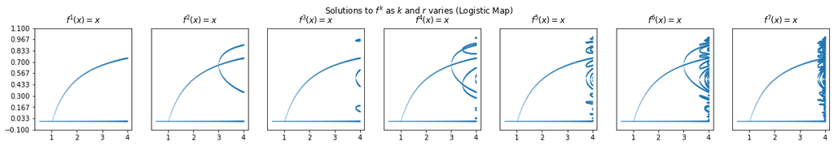

```python
# define r vals
r_vals = 4.5-np.logspace(np.log10(0.5), np.log10(4), 1000)

# create subplots for viewing maps with different r parameters
fig, axes = plt.subplots(nrows = 1, ncols = 7, figsize = [21,3])
fig.subplots_adjust(top = 0.82)
fig.suptitle('Solutions to $f^{{k}}$ as $k$ and $r$ varies ({0})'.format(map_name))
for ax, i in zip(axes, [1,2,3,4,5,6, 7]):
    # iterate the map with a given r value and plot it
    vals = rx_solve(iters = i, tol = 0.00001, r_vals = r_vals, verbose = False)
    ax.plot(vals[:,0], vals[:,1], '.', MarkerSize = 1, alpha = 0.3)
    ax.set_title('$f^{0}(x)=x$'.format(i))
    ax.set_ylim([-0.1,1.1])
    ax.set_yticks([])

# add y-axis tick marks on left-most plot
res = axes[0].set_yticks(np.linspace(-0.1, 1.1, 10))
```

The above plot provides a decent visual of how, near $r=4$, the number of solutions to the equation $f^{k}(x)=x$ exponentially increases with an increasing number of iterations. By inspection at $r=4$, we see 2, 4, 8, and 16 solutions for $f^{k}$ where $k$ goes from one to four. As discussed early, one can imagine how solutions to $f^{k}(x)=x$ with even greater $k$ yield vastly more complex curves -- reflecting the chaos of the logistic map (though maps with stable fixed points can also produce these kinds of plots too without causing chaos).

It is also worth drawing attention to the forming fractal nature of the solutions. For example, compare the solutions for $f^{2}$ with those for $f^{4}(x)$ (the first function that still contains the solutions for $f^{2}$) -- the pitchfork bifurcation in the former occurs several times over in the latter.

Still, its hard to appreciate actual detail of $f^{k}$ as $k$ gets arbitrarily larger -- since each of the above plots only show a fraction of the possible cycles. Let's superimpose all the above cycles together and focus only on the chaotic region:

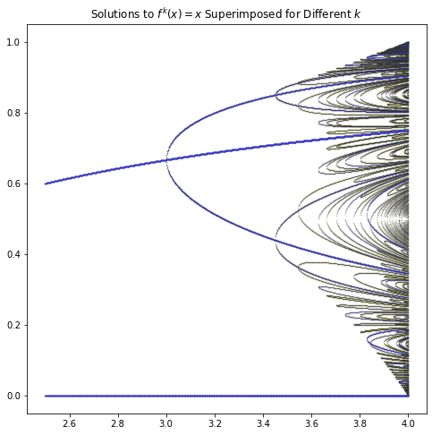

```python
r_num = 1000
r_vals = 6.5-np.logspace(np.log10(2.5), np.log10(4), 1000)

# define iterations and colors
max_iters = 8
# iterations are done in reverse so lower-k cycles are visible first
iters = max_iters - np.linspace(0, max_iters - 1, max_iters).astype('int')
colors = np.linspace(0, 1.0, max_iters)

plt.figure(figsize = [8,8])
plt.title('Solutions to $f^{k}(x)=x$ Superimposed for Different $k$')
for color, i in zip(colors, iters):
    vals = rx_solve(iters = i, tol = 0.00001, r_vals = r_vals, verbose = False)
    plt.plot(vals[:,0], vals[:,1], '.', MarkerSize = 1, alpha = 0.3, color = (0.2,0.2,color), label = "{0} iterations".format(i))
```